# TMC_kaplanmeier_surival_curves

#### Importing Libraries

```python
# Import the required libraries & modules
import pandas as pd
import numpy as np
import matplotlib.pyplot as plt
import seaborn as sns
%matplotlib inline
```

#### DATASET

```python
gbc_patients = pd.read_excel("GBC.xlsx")
```

```python
gbc_patients.head()
```

|  | MR_NO | Comorbidities_final | Thyroidism | Diabetes | HTN | Family_cancer_history | ECOG_final | Gall_stone_final | Pathology | Tumour_grade_final | ... | ALT - SGPT | ALK PHOS [ALP] | GAMMA GT | ALBUMIN | CREATININE_from_UnC_test | UREA_from_UnC_test | ESTIMATED AVERAGE GLUCOSE (eAG) | HbA1c | CREATININE_from_CREATININE_test | Diabetes_final |
| --- | --- | --- | --- | --- | --- | --- | --- | --- | --- | --- | --- | --- | --- | --- | --- | --- | --- | --- | --- | --- | --- |
| 0 | MR/17/000051 | NaN | No | No | Yes | No | 1 | Yes | Adenocarcinoma | Grade 3 | ... | 28.0 | 147.0 | 21.0 | 4.7 | NaN | NaN | 137.0 | 6.4 | 0.64 | Yes |
| 1 | MR/17/000165 | NaN | No | No | No | No | Not known | No | Adenocarcinoma | Grade X | ... | 27.0 | 83.0 | 76.0 | 3.4 | NaN | NaN | NaN | NaN | NaN | No |
| 2 | MR/17/000504 | NaN | Hypothyroidism | Yes | Yes | Not known | Not known | Not known | Adenocarcinoma | Grade 3 | ... | NaN | NaN | NaN | NaN | NaN | NaN | NaN | NaN | NaN | Yes |
| 3 | MR/17/000600 | NaN | No | No | Yes | No | 1 | No | Adenocarcinoma | Grade X | ... | 98.0 | 481.0 | 83.0 | 4.1 | NaN | NaN | 117.0 | 5.7 | 1.08 | Yes |
| 4 | MR/17/000665 | NaN | No | No | No | No | 1 | Not known | Adenocarcinoma | Grade X | ... | 78.0 | 206.0 | 481.0 | 3.2 | NaN | NaN | NaN | NaN | 0.60 | No |

5 rows × 50 columns

#### Basic Idea of our dataset

```python
gbc_patients.info()
```

```
<class 'pandas.core.frame.DataFrame'>
RangeIndex: 698 entries, 0 to 697
Data columns (total 50 columns):
 #   Column                           Non-Null Count  Dtype
---  ------                           --------------  -----
 0   MR_NO                            698 non-null    object
 1   Comorbidities_final              566 non-null    object
 2   Thyroidism                       657 non-null    object
 3   Diabetes                         659 non-null    object
 4   HTN                              659 non-null    object
 5   Family_cancer_history            657 non-null    object
 6   ECOG_final                       660 non-null    object
 7   Gall_stone_final                 657 non-null    object
 8   Pathology                        698 non-null    object
 9   Tumour_grade_final               646 non-null    object
```

[output cut: 42 more lines]

#### Missing Value Analysis

```python
# Check the total missing values in each column.
print("Total NULL Values in each columns")
print("**************************************")
print(gbc_patients.isnull().sum())
```

```
Total NULL Values in each columns
MR_NO                                0
Comorbidities_final                132
Thyroidism                          41
Diabetes                            39
HTN                                 39
Family_cancer_history               41
ECOG_final                          38
Gall_stone_final                    41
Pathology                            0
Tumour_grade_final                  52
Cancer_presentation_final           56
Tumour_stage_final                  78
TNM_classification                  80
Metastasis_final                    66
Site_metastasis                    165
Mets_site_final                     68
Cholecystectomy_TMC                209
Outside_cholecystectomy             41
Surgery_final                       38
Treatment_final                     56
Treatment_clean                     68
Treatment                           68
Status                             114
Date_event                         264
Date_diagnosis                      45
AGE                                  0
GENDER                               0
COUNTRY                              0
STATE_NAME                           0
CITY_NAME                            0
PINCODE                             83
First_Visit_Date                   132
HEIGHT                             132
WEIGHT                             132
BSA_DETAILS                        132
BMI_DETAILS                        132
BILIRUBIN CONJUGATED               273
BILIRUBIN UNCONJUGATED             273
BILIRUBIN TOTAL                    273
AST - SGOT                         273
ALT - SGPT                         274
ALK PHOS [ALP]                     273
GAMMA GT                           275
ALBUMIN                            274
CREATININE_from_UnC_test           677
UREA_from_UnC_test                 677
ESTIMATED AVERAGE GLUCOSE (eAG)    618
HbA1c                              618
CREATININE_from_CREATININE_test    518
Diabetes_final                      39
dtype: int64
```

**No. of patients with defined "Status"**

```python
#count gives the no. of observations excluding the missing data
gbc_patients["Status"].count()
```

```
584
```

**Total no. of patients with defined "Status" = 584"**

```python
gbc_patients["Status"].value_counts()
```

```
Dead         460
Not Known     63
Alive         34
Live          26
No             1
Name: Status, dtype: int64
```

**Out of 584 patients who have defined "Status", 460 = Dead, 63 = Not known, 34 = Alive, 26 = Live, 1=No**

**No. of patients with defined "Date_event"?**

```python
gbc_patients["Date_event"].count()
```

```
434
```

**Total no. of patients with defined "Date_event" = 434**

```python
gbc_patients["Date_diagnosis"].count()
```

```
653
```

**Total no. of patients with defined "Date_diagnosis" = 653**

### Filtering the data on the basis of defined "Status", "Data_event" and Date_diagnosis.

```python
filtered_data = gbc_patients.dropna(subset=[ 'Status','Date_event', 'Date_diagnosis'])
filtered_data.shape
filtered_data["Status"].count()
```

```
426
```

**Total no. of patients taken into analysis will be = 426 patients with defined "Status", "Date_event", "Date_diagnosis".**

*checking the "Status" of available data*

```python
filtered_data["Status"].value_counts()
```

```
Dead    425
No        1
Name: Status, dtype: int64
```

**Total no. of Patients with "Status" = Dead are 425 and "Status" = No is 1.**

#### Checking the "Date_event" and "Date_diagnosis" in order to check the range of "Datetime" feature for our data

```python
print(filtered_data['Date_event'].describe())
print('*********************************')
print(filtered_data['Date_diagnosis'].describe())
```

```
count                     426
unique                    323
top       2019-06-15 00:00:00
freq                        7
first     2017-01-02 00:00:00
last      2021-09-07 00:00:00
Name: Date_event, dtype: object
count                     426
unique                    329
top       2018-05-15 00:00:00
freq                        5
first     2008-08-15 00:00:00
last      2020-02-05 00:00:00
Name: Date_diagnosis, dtype: object
```

**The oldest date in "Date_event" feature = 2017-01-02 i.e. 2nd January 2017.**

**The latest date in "Date_event" feature = 2021-09-07 i.e. 7th September 2021.**

**The oldest date in "Date_diagnosis" feature = 2008-08-15 i.e. 15th August 2008.**

**The latest date in "Date_diagnosis" feature = 2020-02-05 i.e. 5th February 2020.**

**Missing values analysis in our Filtered Data**

```python
# Check the total missing values in each column.
print("Total NULL Values in each columns")
print("**************************************")
print(filtered_data.isnull().sum())
```

```
Total NULL Values in each columns
MR_NO                                0
Comorbidities_final                 74
Thyroidism                          19
Diabetes                            17
HTN                                 17
Family_cancer_history               19
ECOG_final                          16
Gall_stone_final                    18
Pathology                            0
Tumour_grade_final                  22
Cancer_presentation_final           25
Tumour_stage_final                  41
TNM_classification                  43
Metastasis_final                    27
Site_metastasis                     80
Mets_site_final                     28
Cholecystectomy_TMC                129
Outside_cholecystectomy             19
Surgery_final                       16
Treatment_final                     31
Treatment_clean                     34
Treatment                           34
Status                               0
Date_event                           0
Date_diagnosis                       0
AGE                                  0
GENDER                               0
COUNTRY                              0
STATE_NAME                           0
CITY_NAME                            0
PINCODE                              8
First_Visit_Date                    76
HEIGHT                              76
WEIGHT                              76
BSA_DETAILS                         76
BMI_DETAILS                         76
BILIRUBIN CONJUGATED               153
BILIRUBIN UNCONJUGATED             153
BILIRUBIN TOTAL                    153
AST - SGOT                         153
ALT - SGPT                         154
ALK PHOS [ALP]                     153
GAMMA GT                           154
ALBUMIN                            153
CREATININE_from_UnC_test           413
UREA_from_UnC_test                 413
ESTIMATED AVERAGE GLUCOSE (eAG)    379
HbA1c                              379
CREATININE_from_CREATININE_test    308
Diabetes_final                      17
dtype: int64
```

**A lot of variables have significant no. of missing data**

### Checking the no. of different categories in every categorical variables and their respective counts in our filtered data

```python
# Filter columns with object data type
categorical_columns = filtered_data.select_dtypes(include=['object']).columns

# Calculate counts of each category in categorical features
category_counts = {}

for column in categorical_columns:
    counts = filtered_data[column].value_counts()
    category_counts[column] = counts

# Print the counts of each category in categorical features
for column, counts in category_counts.items():
    print(f'Counts for {column}:')
    print(counts)
    print()
```

```
Counts for MR_NO:
MR/17/000051    1
MR/18/015094    1
MR/18/014781    1
MR/18/014136    1
MR/18/014086    1
               ..
MR/17/015787    1
MR/17/015628    1
MR/17/014162    1
MR/17/014043    1
MR/19/001762    1
Name: MR_NO, Length: 426, dtype: int64

Counts for Comorbidities_final:
No                254
Not known          64
Heart disease      17
Lungs disease       9
Kidney disease      4
Other cancer        4
Name: Comorbidities_final, dtype: int64

Counts for Thyroidism:
No                305
Not known          67
Hypothyroidism     35
Name: Thyroidism, dtype: int64

Counts for Diabetes:
No           240
Yes          103
Not known     66
Name: Diabetes, dtype: int64

Counts for HTN:
No           207
Yes          141
Not known     61
Name: HTN, dtype: int64
```

[output cut: 259 more lines]

```
HOOGHLY              21
BURDWAN              19
                     ..
PUNE                  1
GUWAHATI              1
KARIMGANJ             1
BALASORE              1
NAGAON                1
Name: CITY_NAME, Length: 85, dtype: int64

Counts for Diabetes_final:
No           231
Yes          115
Not known     63
Name: Diabetes_final, dtype: int64
```

#### Creating a new feature named as "Time_overall_study" in 'months' by using the logic =

**"Time_overall_study = "Date_event" - "Date_diagnosis"**

```python
# Calculate the difference of Date_event and Date_diagnosis in months
filtered_data['Time_overall_study'] = ((filtered_data['Date_event'] - filtered_data['Date_diagnosis']) / np.timedelta64(1, 'M')).astype(float)

filtered_data.head()
```

|  | MR_NO | Comorbidities_final | Thyroidism | Diabetes | HTN | Family_cancer_history | ECOG_final | Gall_stone_final | Pathology | Tumour_grade_final | ... | ALK PHOS [ALP] | GAMMA GT | ALBUMIN | CREATININE_from_UnC_test | UREA_from_UnC_test | ESTIMATED AVERAGE GLUCOSE (eAG) | HbA1c | CREATININE_from_CREATININE_test | Diabetes_final | Time_overall_study |
| --- | --- | --- | --- | --- | --- | --- | --- | --- | --- | --- | --- | --- | --- | --- | --- | --- | --- | --- | --- | --- | --- |
| 0 | MR/17/000051 | NaN | No | No | Yes | No | 1 | Yes | Adenocarcinoma | Grade 3 | ... | 147.0 | 21.0 | 4.7 | NaN | NaN | 137.0 | 6.4 | 0.64 | Yes | 24.246904 |
| 4 | MR/17/000665 | NaN | No | No | No | No | 1 | Not known | Adenocarcinoma | Grade X | ... | 206.0 | 481.0 | 3.2 | NaN | NaN | NaN | NaN | 0.60 | No | 11.860613 |
| 5 | MR/17/000682 | NaN | No | No | Yes | No | 2 | Yes | Adenocarcinoma | Grade X | ... | NaN | NaN | NaN | NaN | NaN | NaN | NaN | 0.61 | No | 17.248814 |
| 7 | MR/17/001311 | Heart disease | No | Yes | Yes | Not known | 1 | Yes | MiNEN | Grade 2 | ... | 108.0 | 21.0 | 4.6 | NaN | NaN | NaN | NaN | NaN | Yes | 23.852646 |
| 8 | MR/17/001536 | NaN | Hypothyroidism | Not known | Yes | Not known | Not known | Yes | Adenocarcinoma | Grade X | ... | 492.0 | 209.0 | 2.6 | NaN | NaN | NaN | NaN | NaN | Not known | 12.846260 |

5 rows × 51 columns

```python
filtered_data["Time_overall_study"].min(), filtered_data["Time_overall_study"].max()
```

```
(-8.01659171646235, 147.22273557978602)
```

**Negative overall study time period is not possible, therefore having a look at that partiicular datapoint**

```python
# Replace 'column_name' with the actual name of your column
row = filtered_data[filtered_data['Time_overall_study'] == -8.01659171646235]

print(row["Status"])
print(row["Date_event"])
print(row["Date_diagnosis"])
```

```
657    Dead
Name: Status, dtype: object
657   2019-02-23
Name: Date_event, dtype: datetime64[ns]
657   2019-10-25
Name: Date_diagnosis, dtype: datetime64[ns]
```

**Since the status of this person is dead therefore Time_overall_study for this person being negative resembles to Date of event is past as compared to the Date of diagnosis which is a false data i.e. not possible. A patient who has already died cannot have a Diagnosis in future. Therefore removing this false data from our analysis.**

**Date_event = 23 feb 2019 and Date_diagnosis = 25th october 2019, which is not possible**

**Deleting this particular observation from our analysis**

```python
#Time_overall_study feature
value_to_delete = -8.01659171646235

# Delete the row with the specified value
filtered_data = filtered_data[filtered_data['Time_overall_study'] != value_to_delete]

filtered_data.shape
```

```
(425, 51)
```

```python
data=filtered_data.copy()
```

### Replacing "Dead" Status by 1 and "No" by 0 in "Status" feature in order to make our analysis easier.

```python
# Mapping of values to be replaced
status_mapping = {'Dead': 1, 'No': 0}

# Replace values in the "Status" column
data['Status'] = data['Status'].replace(status_mapping)
```

```python
data[["Status"]].value_counts() #counts for respective categories in "Status" feature. 425 patients = Dead, 1 patient = No.
```

```
Status
1         424
0           1
dtype: int64
```

### Exploratory Data Analysis

As per the plots dsplayed in the research paper, considering only three variables for the survival curves as of now.

### 1. Univariate Analysis of Categorical variables

Three variables considered in the analysis -

1. Tumour_stage_final
2. Surgery_final
3. Treatment_final

```python
category_list = ['Tumour_stage_final', 'Surgery_final', 'Treatment_final']

def plotUnivariateAnalysis(data_frame, category_list, rows, cols, figsize):
    fig, axes = plt.subplots(rows, cols, figsize=figsize)
    axes = axes.flatten()

    for i, category in enumerate(category_list):
        ax = axes[i]
        counts = data_frame[category].value_counts()
        missing_count = data_frame[category].isnull().sum()
        total_count = len(data_frame)

        counts.plot(kind='bar', ax=ax)

        ax.set_title(f'{category} Distribution')
        ax.set_xlabel(category)
        ax.set_ylabel('Frequency')

        # Calculate and display percentage text on the bars
        total_valid_count = total_count - missing_count
        for rect in ax.patches:
            height = rect.get_height()
            ax.annotate(f'{height / total_valid_count:.2%}',
                        xy=(rect.get_x() + rect.get_width() / 2, height),
                        xytext=(0, 3),  # 3 points vertical offset
                        textcoords="offset points",
                        ha='center', va='bottom')

        # Display percentage of missing values above the plot
        ax.annotate(f"Missing: {missing_count}/{total_count} ({missing_count / total_count:.2%})",
                    xy=(0.5, 0.95),
                    xycoords='axes fraction',
                    ha='center', fontsize=10, color='red')

    # Hide any unused subplots
    for i in range(len(category_list), rows * cols):
        fig.delaxes(axes[i])

    plt.tight_layout()
    plt.show()
```

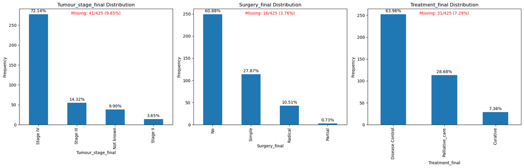

```python
# Call the function to create the grid of plots
plotUnivariateAnalysis(data_frame=data,
                       category_list=category_list,
                       rows=2,
                       cols=3,
                       figsize=(18, 10))
```

#### Data Insight 1:

**`1. ~72% of the population under study had stage 4 tumour, while ~14% had stage 3 tumour, ~9.8% did not have any known stage of tumour, ~3.6% had stage 2 tumour and 9.62% data is missing.`**

**`2. ~61% of the population under study had No surgery, ~27% had simple cholecystectomy, ~10.5% patients had radical cholecystectomy, ~0.73% had partial type and ~3.76% data is missing.`**

**`3. ~64% of the population under study had disease control type treatment,~28% had palliative care, ~7.3% had curative treatment and ~7.28% data is missing.`**

### Survival w.r.t Tumour stage

#### Checking for Missing values in the "Tumour_stage_final" column

```python
data["Tumour_stage_final"].isnull().sum()
```

```
41
```

**41 missing values are present in "Tumour_stage_final" column**

#### Distribution of data w.r.t. Tumour stage

```python
data["Tumour_stage_final"].value_counts()
```

```
Stage IV     277
Stage III     55
Not known     38
Stage II      14
Name: Tumour_stage_final, dtype: int64
```

**Replacing Missing values as a new category, named as "Missing_Data"**

```python
# Assign missing values as "Missing_Data"
data['Tumour_stage_final'] = data['Tumour_stage_final'].fillna("Missing_Data")
```

```python
data['Tumour_stage_final'].value_counts() #41 missing values are to a new category named as Missing_Data
```

```
Stage IV        277
Stage III        55
Missing_Data     41
Not known        38
Stage II         14
Name: Tumour_stage_final, dtype: int64
```

```python
# Extract two features and create a new DataFrame
selected_features = ['Tumour_stage_final', 'Status']
df = data[selected_features]
```

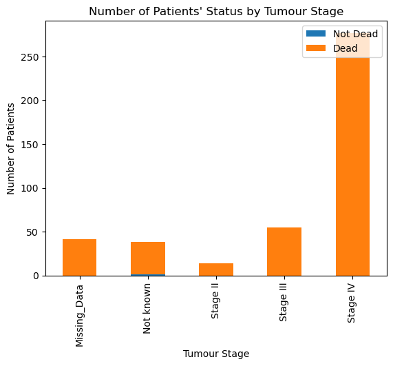

```python
# Group by "Tumour_stage_final" and calculate the counts of 1s and 0s
grouped = df.groupby(['Tumour_stage_final', 'Status']).size().unstack()

# Plot the bar plot
ax = grouped.plot(kind='bar', stacked=True)
plt.title("Number of Patients' Status by Tumour Stage")
plt.xlabel("Tumour Stage")
plt.ylabel("Number of Patients")
plt.legend(['Not Dead', 'Dead'], loc='upper right')
plt.show()
```

**1 Patient who is not dead (blue colour) in our dataset belongs to "Not known" category of the "Tumour_stage_final" feature.**

### KAPLAN-MEIER Survival Curve

```python
#!pip install lifelines
#!pip install scikit-survival
```

```python
data.columns
```

```
Index(['MR_NO', 'Comorbidities_final', 'Thyroidism', 'Diabetes', 'HTN',
       'Family_cancer_history', 'ECOG_final', 'Gall_stone_final', 'Pathology',
       'Tumour_grade_final', 'Cancer_presentation_final', 'Tumour_stage_final',
       'TNM_classification', 'Metastasis_final', 'Site_metastasis',
       'Mets_site_final', 'Cholecystectomy_TMC', 'Outside_cholecystectomy',
       'Surgery_final', 'Treatment_final', 'Treatment_clean', 'Treatment',
       'Status', 'Date_event', 'Date_diagnosis', 'AGE', 'GENDER', 'COUNTRY',
       'STATE_NAME', 'CITY_NAME', 'PINCODE', 'First_Visit_Date', 'HEIGHT',
       'WEIGHT', 'BSA_DETAILS', 'BMI_DETAILS', 'BILIRUBIN CONJUGATED',
       'BILIRUBIN UNCONJUGATED', 'BILIRUBIN TOTAL', 'AST - SGOT', 'ALT - SGPT',
       'ALK PHOS [ALP]', 'GAMMA GT', 'ALBUMIN', 'CREATININE_from_UnC_test',
       'UREA_from_UnC_test', 'ESTIMATED AVERAGE GLUCOSE (eAG)', 'HbA1c',
       'CREATININE_from_CREATININE_test', 'Diabetes_final',
       'Time_overall_study'],
      dtype='object')
```

```python
data.info()
```

```
<class 'pandas.core.frame.DataFrame'>
Int64Index: 425 entries, 0 to 695
Data columns (total 51 columns):
 #   Column                           Non-Null Count  Dtype
---  ------                           --------------  -----
 0   MR_NO                            425 non-null    object
 1   Comorbidities_final              351 non-null    object
 2   Thyroidism                       406 non-null    object
 3   Diabetes                         408 non-null    object
 4   HTN                              408 non-null    object
 5   Family_cancer_history            406 non-null    object
 6   ECOG_final                       409 non-null    object
 7   Gall_stone_final                 407 non-null    object
 8   Pathology                        425 non-null    object
 9   Tumour_grade_final               403 non-null    object
```

[output cut: 43 more lines]

#### converting "Status" feature into boolean for survival analysis

```python
# data
data["Status"] = data["Status"].astype(bool)
```

```
            removed  observed  censored  entrance  at_risk
event_at
0.000000          1         1         0       425      425
0.032855          1         1         0         0      424
0.065710          2         2         0         0      423
0.098565          1         1         0         0      421
0.131420          1         1         0         0      420
...             ...       ...       ...       ...      ...
82.925727         1         1         0         0        5
97.546151         1         1         0         0        4
106.975503        1         1         0         0        3
107.172632        1         1         0         0        2
147.222736        1         1         0         0        1

[320 rows x 5 columns]
```

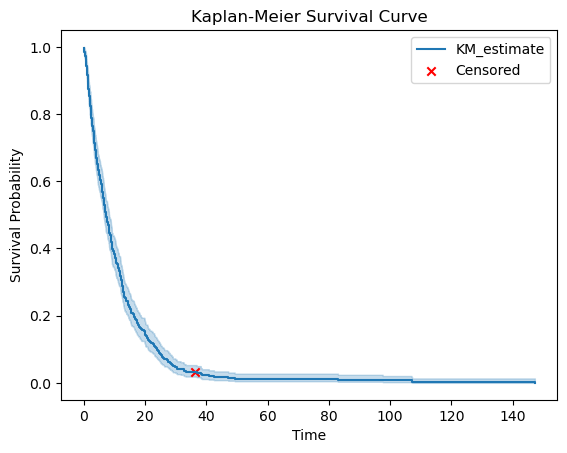

```python
from lifelines import KaplanMeierFitter
#data
df = data
# Initialize KaplanMeierFitter
kmf = KaplanMeierFitter()

# Fit the Kaplan-Meier estimator
kmf.fit(df['Time_overall_study'], event_observed=df['Status'])

# Create a new figure and axes
fig, ax = plt.subplots()

# Plot the Kaplan-Meier survival curve
kmf.plot(ax=ax)

# Plot censored points
censored_data = df[df['Status'] == 0]
ax.scatter(censored_data['Time_overall_study'], kmf.predict(censored_data['Time_overall_study']),
           label='Censored', c='red', marker='x')

# Display the risk data table
risk_table = kmf.event_table
print(risk_table)

# Customize the plot
plt.title("Kaplan-Meier Survival Curve")
plt.xlabel("Time")
plt.ylabel("Survival Probability")
plt.legend()
plt.show()
```

```python
from lifelines import KaplanMeierFitter
kmf = KaplanMeierFitter()

Time = data["Time_overall_study"]
Event = data["Status"]

kmf.fit(Time, event_observed=Event)
```

```
<lifelines.KaplanMeierFitter:"KM_estimate", fitted with 425 total observations, 1 right-censored observations>
```

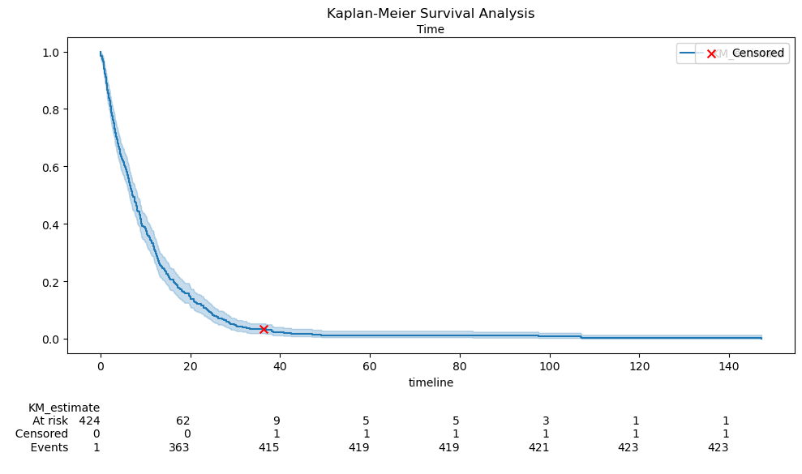

```python
# Perform Kaplan-Meier survival analysis
kmf = KaplanMeierFitter().fit(data["Time_overall_study"], data["Status"])

# Create a larger figure
plt.figure(figsize=(10, 6))  # Adjust the width and height as needed

# Plot the Kaplan-Meier survival function with at-risk counts
kmf.plot_survival_function(at_risk_counts=True)

# Plot censored data points
censored_data = data[data["Status"] == 0]
plt.scatter(censored_data["Time_overall_study"], kmf.predict(censored_data["Time_overall_study"]),
            marker='x', color='red', s=50, label='Censored')

# Add title and labels to the plot
plt.title("Kaplan-Meier Survival Analysis")
plt.xlabel("Time")
plt.ylabel("Survival Probability")
plt.legend()

# Show the plot
plt.tight_layout()
plt.show()
```

```python
#Median time of survival
kmf.median_survival_time_
```

```
7.129509846198074
```

**The overall median survival time for the data available is 7.12 months**

### Confidence Interval for overall Median survival time

```python
from lifelines.utils import median_survival_times
median_ci = median_survival_times(kmf.confidence_interval_)
median_ci
```

|  | KM_estimate_lower_0.95 | KM_estimate_upper_0.95 |
| --- | --- | --- |
| 0.5 | 6.439557 | 8.180866 |

**The 95% confidence interval for the median survival time = 6.43 months to 8.18 months**

### Survival Curve based on Stages of Tumour

```python
data["Tumour_stage_final"].value_counts()
```

```
Stage IV        277
Stage III        55
Missing_Data     41
Not known        38
Stage II         14
Name: Tumour_stage_final, dtype: int64
```

```python
data["Tumour_stage_final"].isnull().sum()
```

```
0
```

**0 Missing values in "Tumour_stage_final" feature**

```
Median survival time for Stage IV: 6.44 months
Risk table for Stage IV:
            removed  observed  censored  entrance  at_risk
event_at
0.000000          0         0         0       277      277
0.032855          1         1         0         0      277
0.065710          1         1         0         0      276
0.131420          1         1         0         0      275
0.295694          1         1         0         0      274
...             ...       ...       ...       ...      ...
49.216616         1         1         0         0        5
82.925727         1         1         0         0        4
97.546151         1         1         0         0        3
107.172632        1         1         0         0        2
147.222736        1         1         0         0        1

[224 rows x 5 columns]
Median survival time for Stage II: 13.34 months
Risk table for Stage II:
           removed  observed  censored  entrance  at_risk
event_at
0.000000         0         0         0        14       14
0.919937         1         1         0         0       14
1.872728         1         1         0         0       13
2.069858         1         1         0         0       12
9.330787         1         1         0         0       11
9.790755         1         1         0         0       10
11.926323        1         1         0         0        9
13.207663        1         1         0         0        8
13.339083        1         1         0         0        7
15.540360        1         1         0         0        6
17.248814        1         1         0         0        5
20.862851        1         1         0         0        4
23.852646        1         1         0         0        3
27.170989        1         1         0         0        2
38.144520        1         1         0         0        1
Median survival time for Not known: 9.07 months
Risk table for Not known:
            removed  observed  censored  entrance  at_risk
event_at
```

[output cut: 124 more lines]

```
11.532064        1         1         0         0       15
11.893468        1         1         0         0       14
12.419146        1         1         0         0       13
12.911969        1         1         0         0       12
13.043389        1         1         0         0       11
14.259020        1         1         0         0       10
14.653278        1         1         0         0        9
16.723136        1         1         0         0        8
18.563010        1         1         0         0        7
25.495390        1         1         0         0        6
28.715169        1         1         0         0        5
29.832235        1         1         0         0        4
30.226493        1         1         0         0        3
30.357913        1         1         0         0        2
32.624900        1         1         0         0        1
```

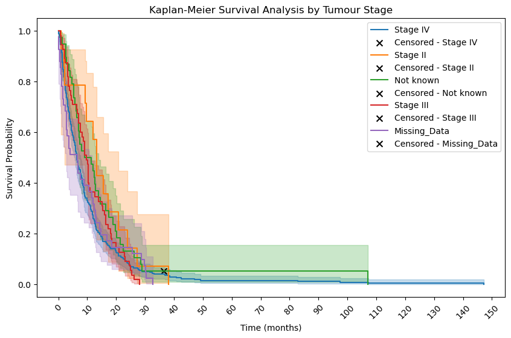

```python
import pandas as pd
import matplotlib.pyplot as plt
from lifelines import KaplanMeierFitter
from lifelines.utils import survival_table_from_events


# data
df = data[["Tumour_stage_final", "Status", "Time_overall_study"]]

# Perform Kaplan-Meier survival analysis for each category
kmf = KaplanMeierFitter()

# Create a larger figure
plt.figure(figsize=(10, 6))  # Adjust the width and height as needed

for category in df["Tumour_stage_final"].unique():
    subset = df[df["Tumour_stage_final"] == category]
    kmf.fit(subset["Time_overall_study"], event_observed=subset["Status"], label=category)

    # Plot the Kaplan-Meier curve
    kmf.plot()

    # Calculate and print median survival time
    median_survival_time = kmf.median_survival_time_
    print(f"Median survival time for {category}: {median_survival_time:.2f} months")

    # Plot censored data points
    censored_data = subset[subset["Status"] == 0]
    plt.scatter(censored_data["Time_overall_study"], kmf.predict(censored_data["Time_overall_study"]),
            marker='x', color='black', s=50, label=f'Censored - {category}')

    # Calculate the risk table
    event_table = survival_table_from_events(subset["Time_overall_study"], subset["Status"])
    print(f"Risk table for {category}:\n{event_table}")

# Add title and labels to the plot
plt.title("Kaplan-Meier Survival Analysis by Tumour Stage")
plt.xlabel("Time (months)")
plt.ylabel("Survival Probability")
plt.legend()

# Change x-axis scale to 5 months
plt.xticks(np.arange(0, 151, 10), rotation=45)

# Show the plot
plt.show()
```

**Since there is only one black cross and that too on the "green" curve, it signifies that 1 observation that is censored, belongs to the "Not Known" category of the "Tumour_stage_final" feature.**

**Median survival time for Stage II: 13.34 months**

**Median survival time for Stage III: 9.69 months**

**Median survival time for Stage IV: 6.44 months**

**Median survival time for Not known: 9.07 months**

**Median survival time for Missing_Data: 6.51 months**

### Survival Curve based on Surgery Type

```python
data["Surgery_final"].value_counts()
```

[output not shown]

```python
data["Surgery_final"].isnull().sum()
```

[output not shown]

**The missing data was assigned to a new category = "Missing_Data" category for seperate analysis**

```python
# Assign missing values as "Missing_Data"
data['Surgery_final'] = data['Surgery_final'].fillna("Missing_Data")
```

```python
data["Surgery_final"].value_counts()
```

```
No              249
Simple          114
Radical          43
Missing_Data     16
Partial           3
Name: Surgery_final, dtype: int64
```

```
Median survival time for Radical: 15.05 months
Risk table for Radical:
           removed  observed  censored  entrance  at_risk
event_at
0.000000         0         0         0        43       43
0.919937         1         1         0         0       43
3.154069         1         1         0         0       42
3.942586         1         1         0         0       41
4.829668         1         1         0         0       40
5.289636         1         1         0         0       39
6.275283         1         1         0         0       38
6.932381         1         1         0         0       37
7.655188         1         1         0         0       36
7.950882         1         1         0         0       35
8.016592         1         1         0         0       34
9.133658         1         1         0         0       33
9.330787         1         1         0         0       32
9.692191         1         1         0         0       31
10.283579        2         2         0         0       30
10.349288        1         1         0         0       28
10.447853        1         1         0         0       27
10.973531        1         1         0         0       26
11.926323        1         1         0         0       25
14.456149        1         1         0         0       24
14.686133        1         1         0         0       23
15.047537        1         1         0         0       22
15.146102        1         1         0         0       21
15.540360        1         1         0         0       20
16.328877        1         1         0         0       19
16.460297        1         1         0         0       18
16.953120        1         1         0         0       17
18.135896        1         1         0         0       16
18.267316        1         1         0         0       15
18.563010        1         1         0         0       14
19.877205        1         1         0         0       13
20.008624        1         1         0         0       12
21.027126        1         1         0         0       11
23.162693        1         1         0         0       10
24.246904        1         1         0         0        9
25.363971        1         1         0         0        8
```

[output cut: 53 more lines]

```
0.000000         1         1         0        16       16
0.394259         1         1         0         0       15
1.051356         1         1         0         0       14
1.511325         1         1         0         0       13
2.956940         1         1         0         0       12
3.581182         2         2         0         0       11
4.106861         1         1         0         0        9
6.505267         1         1         0         0        8
6.735251         1         1         0         0        7
8.837964         1         1         0         0        6
11.893468        1         1         0         0        5
11.959178        1         1         0         0        4
12.419146        1         1         0         0        3
25.495390        1         1         0         0        2
30.357913        1         1         0         0        1
```

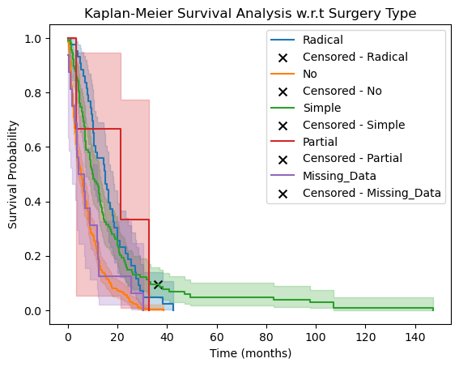

```python
import pandas as pd
import matplotlib.pyplot as plt
from lifelines.utils import survival_table_from_events

# data
df = data[["Surgery_final", "Status", "Time_overall_study"]]

# Perform Kaplan-Meier survival analysis for each category
kmf = KaplanMeierFitter()

for category in df["Surgery_final"].unique():
    subset = df[df["Surgery_final"] == category]
    kmf.fit(subset["Time_overall_study"], event_observed=subset["Status"], label=category)

    # Plot the Kaplan-Meier curve
    kmf.plot()

    # Calculate and print median survival time
    median_survival_time = kmf.median_survival_time_
    print(f"Median survival time for {category}: {median_survival_time:.2f} months")

    # Plot censored data points
    censored_data = subset[subset["Status"] == 0]
    plt.scatter(censored_data["Time_overall_study"], kmf.predict(censored_data["Time_overall_study"]),
            marker='x', color='black', s=50, label=f'Censored - {category}')

    # Calculate the risk table
    event_table = survival_table_from_events(subset["Time_overall_study"], subset["Status"])
    print(f"Risk table for {category}:\n{event_table}")

# Add title and labels to the plot
plt.title("Kaplan-Meier Survival Analysis w.r.t Surgery Type")
plt.xlabel("Time (months)")
plt.ylabel("Survival Probability")
plt.legend()

# Show the plot
plt.show()
```

**Median survival time for No Surgery: 5.29 months**

**Median survival time for Simple: 9.89 months**

**Median survival time for Radical: 15.05 months**

**Median survival time for Partial: 21.36 months**

**Median survival time for Missing_Data: 4.11 months**

```python
df = filtered_data[filtered_data["Status"]=="No"]
```

```python
df["Surgery_final"]
```

```
47    Simple
Name: Surgery_final, dtype: object
```

**Surgery type for 1 censored observation in our data = "simple". Verified.**

#### The analysis that we have performed does not match with the one in the research paper, as our set of data is different from that of the research paper.